# Capsule 2 - Mettre à jour un niveau

MQT-2101 - Analyse et modélisation des données

## Pourquoi ça compte

Quelle part de l’écart faut-il corriger?

Une observation récente peut signaler une évolution durable ou une fluctuation temporaire.

## Objectifs de la capsule

- Mettre à jour le niveau d’un lissage exponentiel simple (SES) avec alpha.
- Comparer deux valeurs d’alpha à partir du même niveau initial.
- Distinguer estimation, tendance et prévision.

## Corriger une fraction de l’écart

$$\ell_t=\alpha y_t+(1-\alpha)\ell_{t-1},\qquad 0<\alpha<1.$$

Le niveau $\ell_t$ corrige une fraction $\alpha$ de l’écart entre la nouvelle observation et le niveau précédent.

On peut aussi écrire $\ell_t=\ell_{t-1}+\alpha(y_t-\ell_{t-1})$.

## Deux réactions à la même hausse

Niveau initial : 100. Deux nouvelles observations : 140, puis 140.

α = 0,2

108 puis 114,4

α = 0,8

132 puis 138,4

Même départ

on isole l’effet d’alpha

## Les poids diminuent avec l’ancienneté

$$\alpha,\quad\alpha(1-\alpha),\quad\alpha(1-\alpha)^2,\quad\ldots$$

- Un alpha élevé réagit davantage à la dernière observation.
- Un alpha faible conserve plus de mémoire.
- Le niveau initial conserve aussi un poids lorsque l’historique est limité.

## Comparer les niveaux sur l’apprentissage

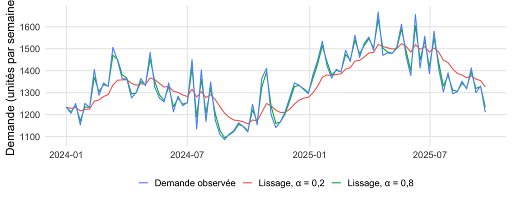

## Imposer ou estimer alpha

- Les valeurs 0,2 et 0,8 sont imposées pour comprendre le mécanisme.
- Pour le SES principal, alpha et le niveau initial sont estimés sur l’apprentissage.
- Alpha est estimé ici à environ 0,371, sans utiliser la validation.

## Un niveau révisable, des prévisions constantes

$$\widehat y_{T+h\mid T}=\ell_T.$$

À origine fixe, le SES prévoit le même niveau à tous les horizons. Il ne modélise ni tendance ni saisonnalité, même si la série R a une fréquence de 52.

## À retenir

Alpha

fraction de l’écart corrigée

Initialisation

à préciser pour comparer

SES

un niveau, sans tendance ni saisonnalité

## Production autonome 7.2

Avec un niveau initial de 100 et deux observations de 140, calculez les mises à jour pour alpha = 0,2 et 0,8. Tracez ces deux lissages sur l’apprentissage, puis estimez le SES principal. Distinguez alpha imposé, alpha estimé et tendance.

### Auto-vérification

- Les deux calculs partagent le même état initial.
- J’obtiens 108 puis 114,4 et 132 puis 138,4.
- J’estime le SES sur l’apprentissage et je sais que ses prévisions sont constantes.